# Unemployment Report

Jeff Krueger, Corey Lund, Fred Mwangi, and Nemanja Orescanin

11/29/2020

```r
library(devtools)
library(blsAPI)
library(rjson)
library(curl)
library(RCurl)
library(knitr)
library(readr)
library(dplyr)
library(tidyverse)
library(rmarkdown)
library(pastecs)
```

```r
library(ggplot2)
library(corrplot)
library(lmtest)
library(forecast)
#loads the necessary packages
```

First we need to load the libraries that we will be using into our report. The above code should load the proper libraries. R Studio will prompt you to install the packages if necessary.

```r
merged_final <- read_csv("csv files/mergedFinal.csv")
#Reads final file into merged dataframe

merged_final$log_pop = as.numeric(log(merged_final$population))

merged_final$log_RMHI = as.numeric(log(merged_final$RMHI))
```

As a final step in scrubbing our data, we created new variables to log the population and median household income variables and store it in our dataframe. By taking the logarithmic values, these variables become more comparable to the existing variables we have within our dataset.

Below you can see the table output once all of our data has been merged.

```r
kable(merged_final[1:6,], caption = "Table Including All Variables")
```

Table Including All Variables

| year | period | periodName | value | state | quarter | annual | HPI | MHI | RMHI | poverty | population | sp500 | log_pop | log_RMHI |
| --- | --- | --- | --- | --- | --- | --- | --- | --- | --- | --- | --- | --- | --- | --- |
| 1984 | M12 | December | 9.3 | AK | 4 | 1 | 153.82 | 32356 | 74689 | 9.6 | 513702 | 1.40 | 13.14940 | 11.22109 |
| 1985 | M12 | December | 10.1 | AK | 4 | 1 | 143.07 | 34782 | 77625 | 8.7 | 532495 | 26.33 | 13.18533 | 11.25964 |
| 1986 | M12 | December | 11.0 | AK | 4 | 1 | 138.24 | 31356 | 68775 | 11.4 | 544268 | 14.62 | 13.20720 | 11.13860 |
| 1987 | M12 | December | 9.5 | AK | 4 | 1 | 106.02 | 33233 | 70468 | 12.0 | 539309 | 2.03 | 13.19804 | 11.16291 |
| 1988 | M12 | December | 8.0 | AK | 4 | 1 | 133.16 | 33103 | 67745 | 11.0 | 541983 | 12.40 | 13.20299 | 11.12351 |
| 1989 | M12 | December | 7.1 | AK | 4 | 1 | 102.92 | 36006 | 70599 | 10.5 | 547159 | 27.25 | 13.21249 | 11.16477 |

```r
#Descriptive Statistics
stat.desc(merged_final)
```

```
##                      year period periodName        value state quarter annual
## nbr.val      1.800000e+03     NA         NA 1.800000e+03    NA    1800   1800
## nbr.null     0.000000e+00     NA         NA 0.000000e+00    NA       0      0
## nbr.na       0.000000e+00     NA         NA 0.000000e+00    NA       0      0
## min          1.984000e+03     NA         NA 1.800000e+00    NA       4      1
## max          2.018000e+03     NA         NA 1.440000e+01    NA       4      1
## range        3.400000e+01     NA         NA 1.260000e+01    NA       0      0
## sum          3.602250e+06     NA         NA 9.793800e+03    NA    7200   1800
## median       2.001500e+03     NA         NA 5.100000e+00    NA       4      1
## mean         2.001250e+03     NA         NA 5.441000e+00    NA       4      1
## SE.mean      2.373587e-01     NA         NA 4.648803e-02    NA       0      0
## CI.mean.0.95 4.655278e-01     NA         NA 9.117621e-02    NA       0      0
## var          1.014105e+02     NA         NA 3.890047e+00    NA       0      0
## std.dev      1.007028e+01     NA         NA 1.972320e+00    NA       0      0
## coef.var     5.031994e-03     NA         NA 3.624922e-01    NA       0      0
##                       HPI          MHI         RMHI      poverty   population
## nbr.val      1.800000e+03 1.800000e+03 1.800000e+03 1.800000e+03 1.800000e+03
## nbr.null     0.000000e+00 0.000000e+00 0.000000e+00 0.000000e+00 0.000000e+00
## nbr.na       0.000000e+00 0.000000e+00 0.000000e+00 0.000000e+00 0.000000e+00
## min          7.925000e+01 1.543000e+04 3.491600e+04 2.900000e+00 4.536900e+05
## max          7.968600e+02 8.634500e+04 8.634500e+04 2.720000e+01 3.955705e+07
## range        7.176100e+02 7.091500e+04 5.142900e+04 2.430000e+01 3.910336e+07
## sum          4.682747e+05 7.505899e+07 1.037364e+08 2.312780e+04 1.018931e+10
## median       2.396650e+02 4.109850e+04 5.678950e+04 1.230000e+01 3.904475e+06
## mean         2.601526e+02 4.169944e+04 5.763133e+04 1.284878e+01 5.660728e+06
## SE.mean      2.820962e+00 3.137450e+02 2.245659e+02 8.704734e-02 1.475374e+05
## CI.mean.0.95 5.532707e+00 6.153429e+02 4.404374e+02 1.707245e-01 2.893626e+05
## var          1.432409e+04 1.771846e+08 9.077371e+07 1.363903e+01 3.918109e+13
## std.dev      1.196833e+02 1.331107e+04 9.527524e+03 3.693106e+00 6.259480e+06
## coef.var     4.600503e-01 3.192147e-01 1.653185e-01 2.874286e-01 1.105773e+00
##                      sp500      log_pop     log_RMHI
## nbr.val       1800.0000000 1.800000e+03 1.800000e+03
## nbr.null        50.0000000 0.000000e+00 0.000000e+00
## nbr.na           0.0000000 0.000000e+00 0.000000e+00
## min            -38.4900000 1.302517e+01 1.046070e+01
## max             34.1100000 1.749325e+01 1.136611e+01
## range           72.6000000 4.468085e+00 9.054057e-01
## sum          17061.0000000 2.711241e+04 1.970673e+04
## median          11.8950000 1.517763e+01 1.094711e+01
## mean             9.4783333 1.506245e+01 1.094819e+01
## SE.mean          0.3699741 2.388216e-02 3.901516e-03
## CI.mean.0.95     0.7256242 4.683969e-02 7.651979e-03
## var            246.3855447 1.026644e+00 2.739929e-02
## std.dev         15.6966730 1.013234e+00 1.655273e-01
## coef.var         1.6560583 6.726890e-02 1.511915e-02
```

The dependent variable, value, has a mean of 5.44 and a standard deviation of 1.97. Connecticut and Virginia had the lowest unemployment rate in 2000 at 1.8, while West Virginia was the highest in 1984 at 14.4. The mean HPI was 260.15, with a standard deviation of 119.68. The lowest HPI was found in Wyoming in 1987 at 79.25, while the highest was in Massachusetts in 2018 at 796.86. Poverty rate had a mean of 12.85 and a standard deviation of 3.69. In 1989, Connecticut had the lowest rate of 2.9, and Mississippi had the highest at 27.2 in 1988. The sp500 index mean was 9.48, and the standard deviation was 15.70. In 2008, the lowest index was seen at -38.4, while the highest index was seen in 1995 at 34.11. The logged population mean was 15.06, and the standard deviation was 1.01. Wyoming had the lowest logged population at 13.025 in 1990, California having the highest in 2018 at 17.49. Logged real median household income had a mean of 10.95 and a standard deviation of 0.17. In 2013, Mississippi had the lowest log_RMHI at 10.46, while Massachusetts had the highest in 2018 at 11.37.

After our data was merged we binned the states into groups based on the mean population of the years in our dataframe (1984-2018). Below are the bins that were created:

Population < 2,000,000 WV, NM, NE, ID, ME, HI, NH, RI, MT, DE, SD, ND, AK, VT, WY

2,000,000 < Population < 5,000,000 MN, AL, LA, CO, SC, KY, OK, OR, CT, IA, MS, KS, AR, UT, NV

5,000,000 < Population < 10,000,000 MI, NJ, GA, NC, VA, MA, IN, WA, TN, MO, WI, MD, AZ

Population > 10,000,000 CA, TX, NY, FL, PA, IL, OH

Each member of our group performed some basic analysis on the states within one of the bins. After performing our initial analysis we chose to focus on 2 states within each bin. The states we chose to focus on are: TX, IL, MO, WA, OR, CO, WV, ME

Below are some of the highlights along with commentary for the states we have chosen to focus on

```r
IL_data <- merged_final[ merged_final$state == "IL", ]
```

```r
#Descriptive statistics
stat.desc(IL_data)
```

```
##                      year period periodName       value state quarter annual
## nbr.val      3.600000e+01     NA         NA  36.0000000    NA      36     36
## nbr.null     0.000000e+00     NA         NA   0.0000000    NA       0      0
## nbr.na       0.000000e+00     NA         NA   0.0000000    NA       0      0
## min          1.984000e+03     NA         NA   4.1000000    NA       4      1
## max          2.018000e+03     NA         NA  11.0000000    NA       4      1
## range        3.400000e+01     NA         NA   6.9000000    NA       0      0
## sum          7.204500e+04     NA         NA 231.7000000    NA     144     36
## median       2.001500e+03     NA         NA   6.1000000    NA       4      1
## mean         2.001250e+03     NA         NA   6.4361111    NA       4      1
## SE.mean      1.701715e+00     NA         NA   0.3023493    NA       0      0
## CI.mean.0.95 3.454665e+00     NA         NA   0.6138018    NA       0      0
## var          1.042500e+02     NA         NA   3.2909444    NA       0      0
## std.dev      1.021029e+01     NA         NA   1.8140960    NA       0      0
## coef.var     5.101956e-03     NA         NA   0.2818621    NA       0      0
##                      HPI          MHI         RMHI     poverty   population
## nbr.val        36.000000 3.600000e+01 3.600000e+01  36.0000000 3.600000e+01
## nbr.null        0.000000 0.000000e+00 0.000000e+00   0.0000000 0.000000e+00
## nbr.na          0.000000 0.000000e+00 0.000000e+00   0.0000000 0.000000e+00
## min           112.800000 2.375200e+04 5.482800e+04   9.9000000 1.138726e+07
## max           371.210000 7.014500e+04 7.014500e+04  15.6000000 1.289827e+07
## range         258.410000 4.639300e+04 1.531700e+04   5.7000000 1.511012e+06
## sum          9218.510000 1.587843e+06 2.204043e+06 451.4000000 4.422845e+08
## median        276.190000 4.607050e+04 6.109050e+04  12.6000000 1.250700e+07
## mean          256.069722 4.410675e+04 6.122342e+04  12.5388889 1.228568e+07
## SE.mean        13.176322 1.969590e+03 6.769020e+02   0.2635917 9.375302e+04
## CI.mean.0.95   26.749355 3.998480e+03 1.374184e+03   0.5351197 1.903288e+05
## var          6250.156368 1.396542e+08 1.649507e+07   2.5013016 3.164266e+11
## std.dev        79.057930 1.181754e+04 4.061412e+03   1.5815504 5.625181e+05
## coef.var        0.308736 2.679304e-01 6.633756e-02   0.1261316 4.578648e-02
##                   sp500      log_pop     log_RMHI
## nbr.val       36.000000 3.600000e+01 3.600000e+01
## nbr.null       1.000000 0.000000e+00 0.000000e+00
## nbr.na         0.000000 0.000000e+00 0.000000e+00
## min          -38.490000 1.624801e+01 1.091196e+01
## max           34.110000 1.637260e+01 1.115832e+01
## range         72.600000 1.245982e-01 2.463635e-01
## sum          341.220000 5.876247e+02 3.967264e+02
## median        11.895000 1.634180e+01 1.102010e+01
## mean           9.478333 1.632291e+01 1.102018e+01
## SE.mean        2.652485 7.733796e-03 1.093321e-02
## CI.mean.0.95   5.384831 1.570044e-02 2.219560e-02
## var          253.284340 2.153217e-03 4.303264e-03
## std.dev       15.914909 4.640277e-02 6.559927e-02
## coef.var       1.679083 2.842801e-03 5.952651e-03
```

```r
#pairwise correlations
sapply(IL_data, class)
```

```
##        year      period  periodName       value       state     quarter
##   "numeric" "character" "character"   "numeric" "character"   "numeric"
##      annual         HPI         MHI        RMHI     poverty  population
##   "numeric"   "numeric"   "numeric"   "numeric"   "numeric"   "numeric"
##       sp500     log_pop    log_RMHI
##   "numeric"   "numeric"   "numeric"
```

```r
sapply(IL_data, is.factor)
```

```
##       year     period periodName      value      state    quarter     annual
##      FALSE      FALSE      FALSE      FALSE      FALSE      FALSE      FALSE
##        HPI        MHI       RMHI    poverty population      sp500    log_pop
##      FALSE      FALSE      FALSE      FALSE      FALSE      FALSE      FALSE
##   log_RMHI
##      FALSE
```

```r
cor(IL_data[sapply(IL_data, function(x) !is.character(x))])
```

```
##                    year        value quarter annual         HPI        MHI
## year        1.000000000  0.006748569      NA     NA  0.91598238  0.9754798
## value       0.006748569  1.000000000      NA     NA -0.08115831 -0.1343498
## quarter              NA           NA       1     NA          NA         NA
## annual               NA           NA      NA      1          NA         NA
## HPI         0.915982382 -0.081158315      NA     NA  1.00000000  0.9020434
## MHI         0.975479844 -0.134349785      NA     NA  0.90204345  1.0000000
## RMHI        0.369670810 -0.659000548      NA     NA  0.39861034  0.5518278
## poverty    -0.360502692  0.697578917      NA     NA -0.47108192 -0.5052706
## population  0.955653199  0.020119683      NA     NA  0.93700387  0.9194634
## sp500      -0.138529275  0.031097916      NA     NA -0.21926746 -0.1520508
## log_pop     0.953215398  0.011231165      NA     NA  0.93704886  0.9183431
## log_RMHI    0.373224106 -0.660277555      NA     NA  0.40824269  0.5536662
##                   RMHI     poverty  population       sp500     log_pop
## year        0.36967081 -0.36050269  0.95565320 -0.13852928  0.95321540
## value      -0.65900055  0.69757892  0.02011968  0.03109792  0.01123117
## quarter             NA          NA          NA          NA          NA
## annual              NA          NA          NA          NA          NA
## HPI         0.39861034 -0.47108192  0.93700387 -0.21926746  0.93704886
## MHI         0.55182782 -0.50527064  0.91946339 -0.15205085  0.91834308
## RMHI        1.00000000 -0.86935532  0.36060017 -0.04610779  0.36698125
## poverty    -0.86935532  1.00000000 -0.40348032  0.08946888 -0.41069905
## population  0.36060017 -0.40348032  1.00000000 -0.15320230  0.99988750
## sp500      -0.04610779  0.08946888 -0.15320230  1.00000000 -0.15281783
## log_pop     0.36698125 -0.41069905  0.99988750 -0.15281783  1.00000000
## log_RMHI    0.99934815 -0.87399522  0.36621331 -0.04538721  0.37261639
##               log_RMHI
## year        0.37322411
## value      -0.66027755
## quarter             NA
## annual              NA
## HPI         0.40824269
## MHI         0.55366622
## RMHI        0.99934815
## poverty    -0.87399522
## population  0.36621331
## sp500      -0.04538721
## log_pop     0.37261639
## log_RMHI    1.00000000
```

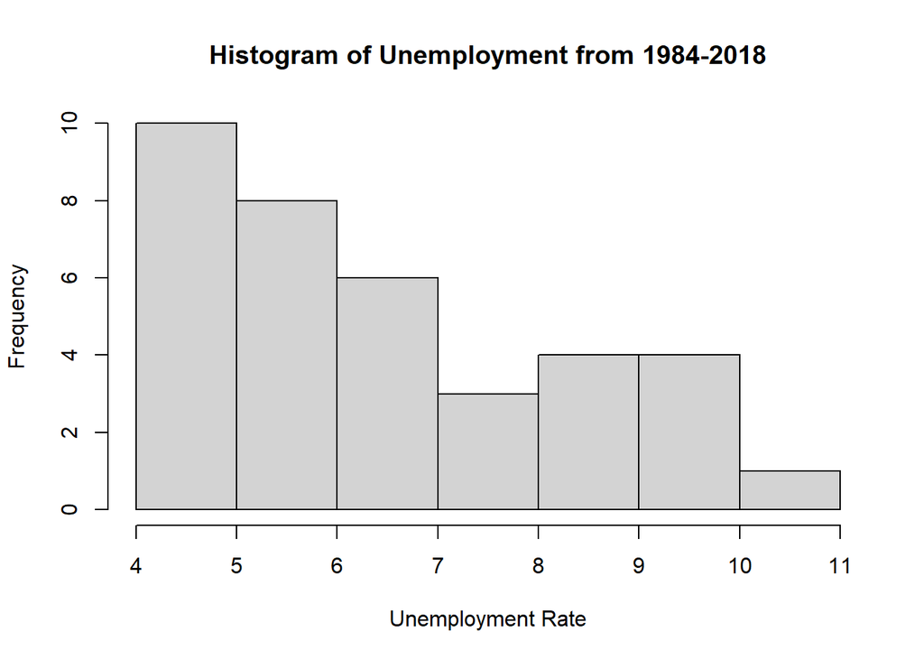

```r
hist(IL_data$value,
     main="Histogram of Unemployment from 1984-2018",
     xlim=c(4,11),
     xlab="Unemployment Rate",
     breaks = 5)
```

Histograms graphically summarize the distribution of a data set. In Illinois, from 1984 to 2018, The annual unemployment rates ranged from 4.0-11.0%. The histogram displays a positively skewed distribution. An unemployment rate that fell within the first two intervals, 4.0-4.9% & 5.0-5.9%, occurred 18 out of the 36 years examined.

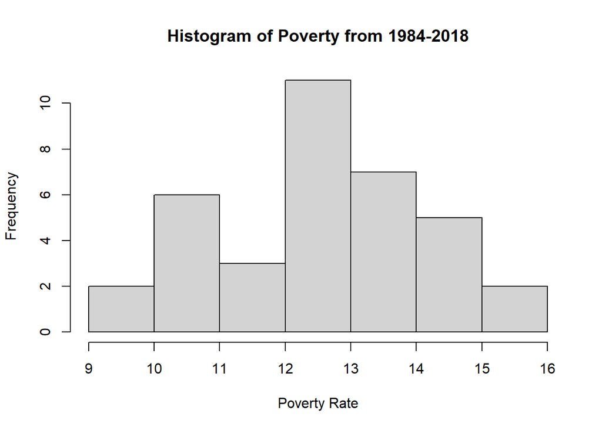

```r
hist(IL_data$poverty,
     main="Histogram of Poverty from 1984-2018",
     xlim=c(9,16),
     xlab="Poverty Rate",
     breaks = 5)
```

In Illinois, from 1984 to 2018, the poverty levels ranged from 9.0-16.0%. The histogram displays a relatively normal distribution. Between 12.0-12.9% was the most frequently recorded interval during this time period. In 14 of the 36 years examined, the poverty rate in Illinois was between 13-15.9%.

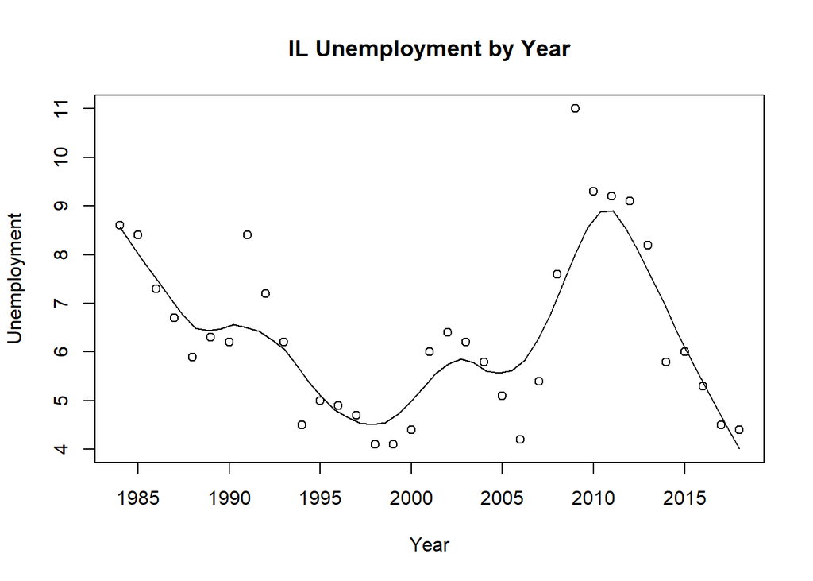

```r
scatter.smooth(IL_data$year, IL_data$value, main="IL Unemployment by Year", xlab = "Year", ylab = "Unemployment", span = 2/8)
```

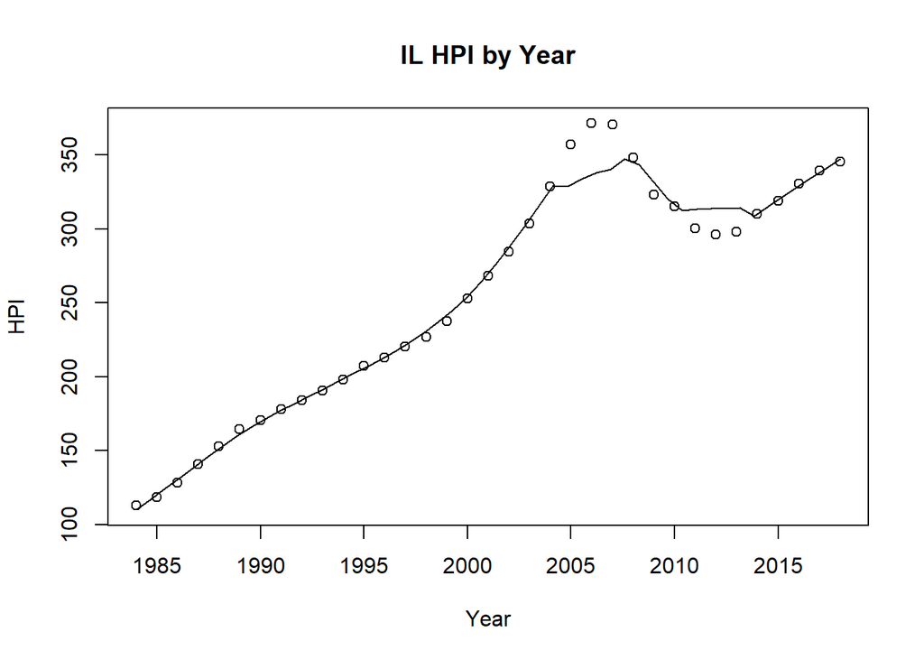

```r
scatter.smooth(IL_data$year, IL_data$HPI, main="IL HPI by Year", xlab = "Year", ylab = "HPI", span = 2/8)
```

This plot represents the relationship between Illinois’ median housing price index (HPI) and the year. From 1984 to 2008 the relationship appeared to be linear until the HPI dipped in 2008-2013. Since then, the HPI began to continue its increase in a linear fashion. This pattern is observed consistently when examining many other states and, through inference, can partially be attributed to the housing crisis that occurred in 2008 and 2009.

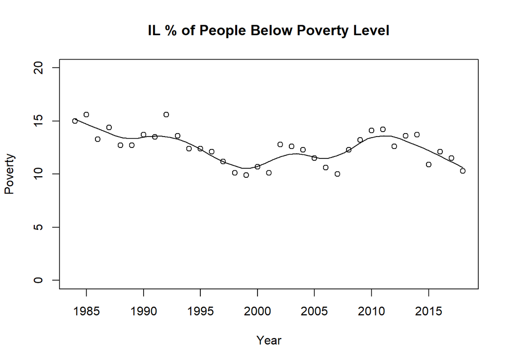

```r
scatter.smooth(x=IL_data$year, y=IL_data$poverty, main="IL % of People Below Poverty Level", xlab = "Year", ylab = "Poverty", ylim = c(0,20), span = 2/8)
```

The percentage of individuals living below the poverty rate in Illinois does not display a clear pattern. Overall, there has been slight decrease of roughly 4% from 1984 to 2018. Poverty levels peaked in 1992.

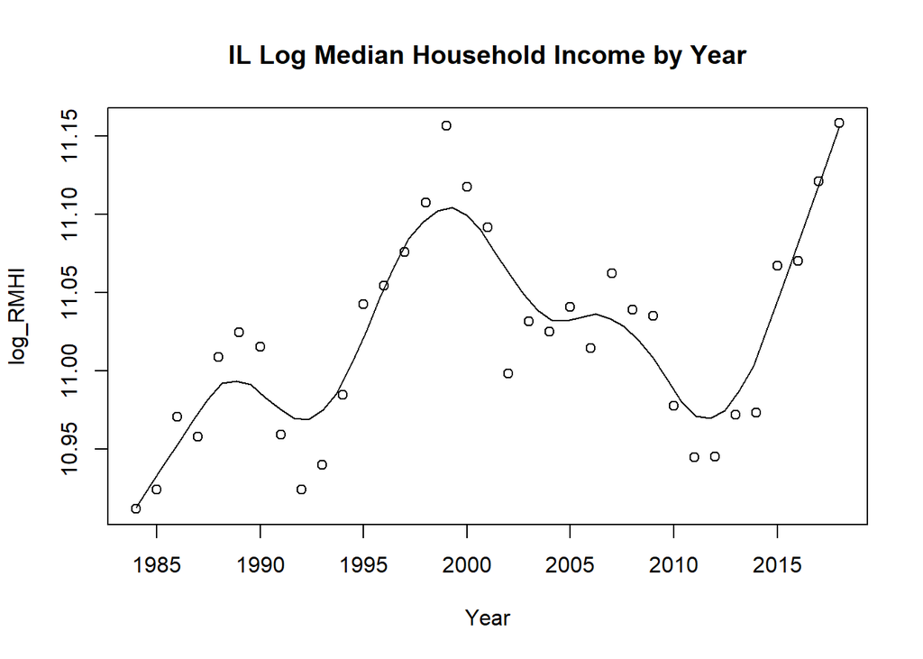

```r
#IL_data$log_RMHI <- as.integer(IL_data$log_RMHI)
scatter.smooth(x=IL_data$year, y=IL_data$log_RMHI, main="IL Log Median Household Income by Year", xlab = "Year", ylab = "log_RMHI", span = 2/8 )
```

The median household income in Illinois increased dramatically from 1984-2018. The lowest and highest values recorded fell at the beginning and the end of the time period, respectively.

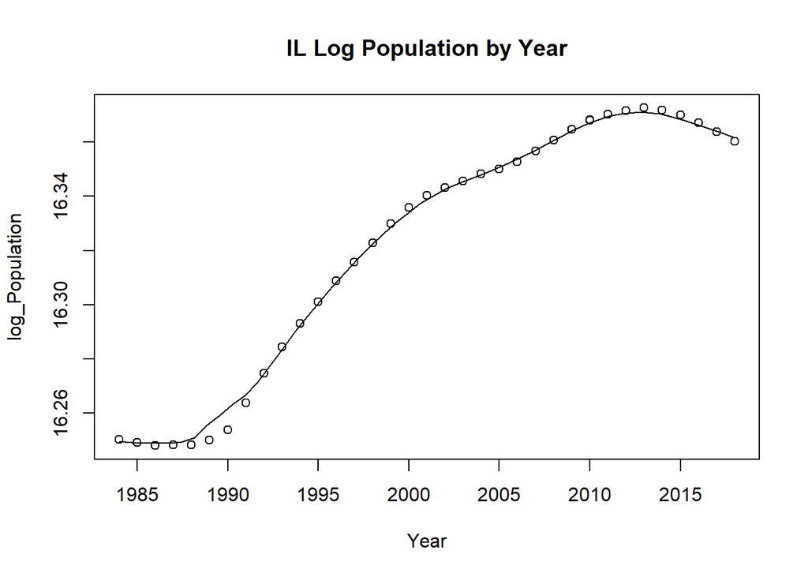

```r
#IL_data$log_pop <- as.integer(IL_data$log_pop)
scatter.smooth(x=IL_data$year, y=IL_data$log_pop, main="IL Log Population by Year", xlab = "Year", ylab = "log_Population", span = 2/8)
```

The log population of Illinois decreased from 1984-1988 before increasing in a relatively linear fashion from 1988 to its peak in 2013. 2013-2018 is characterized by a gradual decline in population.

```r
cor(IL_data$RMHI, IL_data$value)
```

```
## [1] -0.6590005
```

```r
cor(IL_data$HPI, IL_data$value)
```

```
## [1] -0.08115831
```

```r
cor(IL_data$poverty, IL_data$value)
```

```
## [1] 0.6975789
```

```r
cor(IL_data$population, IL_data$value)
```

```
## [1] 0.02011968
```

```r
cor(IL_data$sp500, IL_data$value)
```

```
## [1] 0.03109792
```

```r
cor(IL_data$log_pop, IL_data$value)
```

```
## [1] 0.01123117
```

```r
cor(IL_data$log_RMHI, IL_data$value)
```

```
## [1] -0.6602776
```

```r
#run base correlations between categories and dependent variable
```

A correlation function is used to illustrate the relationship between our independent variable and our dependent variable. The closer the correlation is to 1 or -1 the stronger the correlation between the two variables. For a correlation of 1, it signifies that there is a perfect positive correlation. For a -1 correlation there is a perfect inverse relationship between the two variables.

The correlation between HPI (Housing Price Index) and our dependent variable, unemployment, in Illinois is -0.08115831. The correlation shows that there is a weak negative relationship between the housing price index and unemployment.

The correlation between poverty, the percentage of the population under the poverty line, and unemployment in Illinois is 0.6975789. This correlation shows a much stronger positive relationship between the two variables. As unemployment increases there is a much stronger possibility that the percentage of the population under the poverty line increasing as well.

The correlation between the population and unemployment in Illinois is 0.02011968. The correlation between population and unemployment is a weak positive correlation. The correlation is extremely close to 0, which signified that there is no direct correlation between the two variables.

The correlation between the s&p 500 and unemployment in Illinois is 0.03109792. The correlation between the S&P 500 and unemployment is a weak positive correlation. With the correlation being extremely close to 0 it signifies that there is not much of a correlation between the two variables.

The correlation between the log of the population and unemployment in Illinois is 0.01123117. The correlation between the log of the population and unemployment is extremely close to 0, which signifies there is almost no correlation between the two variables.

The correlation between the log of median household income and unemployment in Illinois is -0.6602776. The correlation between the log of median household income and unemployment is a strong negative correlation. A strong negative correlation suggests that the two variables move in inverse directions of each other. In this case, -0.66 suggests that there is enough evidence to suggest that in most cases the two variables move in inverse directions of each other due to the proximity of -0.66 to -1 which is a perfect negative relationship.

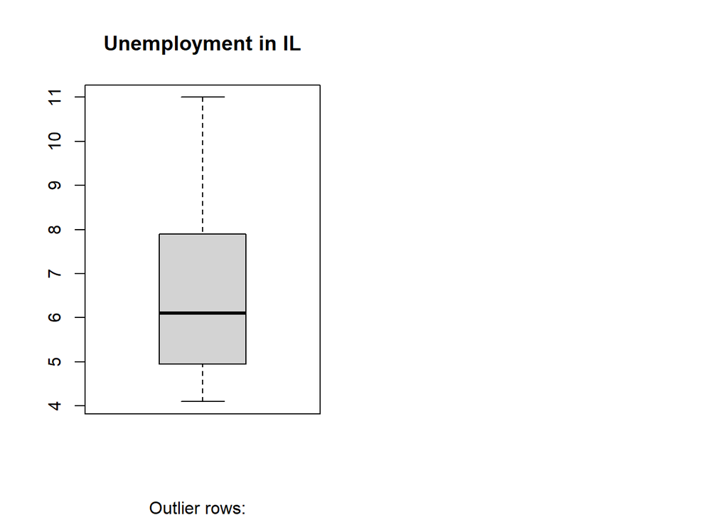

```r
par(mfrow=c(1, 2))  # divide graph area in 2 columns
boxplot(IL_data$value, main="Unemployment in IL", sub=paste("Outlier rows: ", boxplot.stats(IL_data$value)$out))  # box plot for 'Unemployment'
```

The annual unemployment rate in Illinois ranged from 4%-11% from 1984-2018. The boxplot displays a positively skewed distribution meaning the mean is greater than the median. There were no outliers in the Unemployment data collected from 1984-2018 based upon the boxplot results.

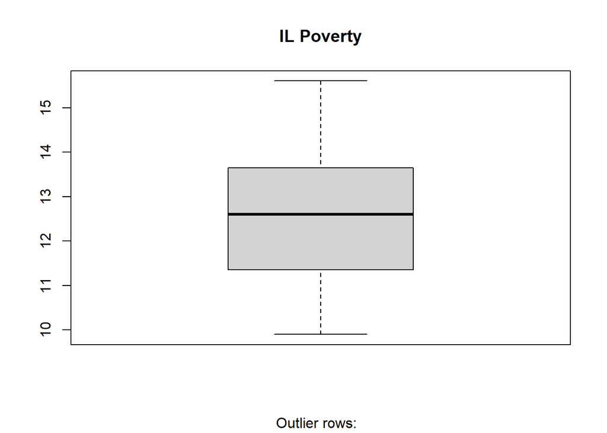

```r
boxplot(IL_data$poverty, main="IL Poverty", sub=paste("Outlier rows: ", boxplot.stats(IL_data$poverty)$out))  # box plot for 'Poverty'
```

```r
#create box plot for poverty level and unemployment level
```

```r
#run multiple linear model for data
IL_reg1 <- lm(value ~ poverty + RMHI + HPI + population + sp500, data = IL_data)
summary(IL_reg1)
```

```
##
## Call:
## lm(formula = value ~ poverty + RMHI + HPI + population + sp500,
##     data = IL_data)
##
## Residuals:
##     Min      1Q  Median      3Q     Max
## -2.5866 -0.7214 -0.0935  0.7777  3.6103
##
## Coefficients:
##               Estimate Std. Error t value Pr(>|t|)
## (Intercept) -1.676e+01  1.379e+01  -1.215   0.2337
## poverty      6.896e-01  2.776e-01   2.484   0.0188 *
## RMHI        -1.113e-04  1.033e-04  -1.077   0.2901
## HPI         -5.417e-03  8.027e-03  -0.675   0.5050
## population   1.851e-06  1.075e-06   1.723   0.0952 .
## sp500        2.284e-04  1.343e-02   0.017   0.9865
## ---
## Signif. codes:  0 '***' 0.001 '**' 0.01 '*' 0.05 '.' 0.1 ' ' 1
##
## Residual standard error: 1.217 on 30 degrees of freedom
## Multiple R-squared:  0.6143, Adjusted R-squared:  0.5501
## F-statistic: 9.558 on 5 and 30 DF,  p-value: 1.561e-05
```

```r
anova(IL_reg1)
```

```
## Analysis of Variance Table
##
## Response: value
##            Df Sum Sq Mean Sq F value    Pr(>F)
## poverty     1 56.050  56.050 37.8541 9.109e-07 ***
## RMHI        1  1.303   1.303  0.8798   0.35574
## HPI         1  8.899   8.899  6.0102   0.02026 *
## population  1  4.510   4.510  3.0461   0.09117 .
## sp500       1  0.000   0.000  0.0003   0.98654
## Residuals  30 44.420   1.481
## ---
## Signif. codes:  0 '***' 0.001 '**' 0.01 '*' 0.05 '.' 0.1 ' ' 1
```

```r
IL_reg2 <- lm(value ~ poverty + log_RMHI + HPI + log_pop + sp500, data = IL_data)
summary(IL_reg2)
```

```
##
## Call:
## lm(formula = value ~ poverty + log_RMHI + HPI + log_pop + sp500,
##     data = IL_data)
##
## Residuals:
##     Min      1Q  Median      3Q     Max
## -2.5575 -0.7142 -0.0868  0.7908  3.6217
##
## Coefficients:
##               Estimate Std. Error t value Pr(>|t|)
## (Intercept) -2.701e+02  2.170e+02  -1.245   0.2228
## poverty      6.973e-01  2.810e-01   2.481   0.0189 *
## log_RMHI    -6.889e+00  6.524e+00  -1.056   0.2994
## HPI         -4.554e-03  7.999e-03  -0.569   0.5733
## log_pop      2.113e+01  1.303e+01   1.621   0.1154
## sp500        5.088e-04  1.349e-02   0.038   0.9702
## ---
## Signif. codes:  0 '***' 0.001 '**' 0.01 '*' 0.05 '.' 0.1 ' ' 1
##
## Residual standard error: 1.222 on 30 degrees of freedom
## Multiple R-squared:  0.6109, Adjusted R-squared:  0.546
## F-statistic: 9.418 on 5 and 30 DF,  p-value: 1.773e-05
```

```r
anova(IL_reg2)
```

```
## Analysis of Variance Table
##
## Response: value
##           Df Sum Sq Mean Sq F value   Pr(>F)
## poverty    1 56.050  56.050 37.5138 9.84e-07 ***
## log_RMHI   1  1.249   1.249  0.8358  0.36789
## HPI        1  9.011   9.011  6.0310  0.02007 *
## log_pop    1  4.048   4.048  2.7091  0.11022
## sp500      1  0.002   0.002  0.0014  0.97017
## Residuals 30 44.823   1.494
## ---
## Signif. codes:  0 '***' 0.001 '**' 0.01 '*' 0.05 '.' 0.1 ' ' 1
```

```r
IL_linearModelSignificant <- lm(value ~ poverty + log_pop, data = IL_data)
summary(IL_linearModelSignificant)
```

```
##
## Call:
## lm(formula = value ~ poverty + log_pop, data = IL_data)
##
## Residuals:
##     Min      1Q  Median      3Q     Max
## -2.4468 -0.7344 -0.1555  0.7208  3.3382
##
## Coefficients:
##              Estimate Std. Error t value Pr(>|t|)
## (Intercept) -234.2508    78.4390  -2.986  0.00529 **
## poverty        0.9689     0.1397   6.937  6.3e-08 ***
## log_pop       14.0011     4.7604   2.941  0.00594 **
## ---
## Signif. codes:  0 '***' 0.001 '**' 0.01 '*' 0.05 '.' 0.1 ' ' 1
##
## Residual standard error: 1.192 on 33 degrees of freedom
## Multiple R-squared:  0.5932, Adjusted R-squared:  0.5686
## F-statistic: 24.06 on 2 and 33 DF,  p-value: 3.581e-07
```

```r
WV_data <- merged_final[ merged_final$state == "WV", ]
```

```r
#Descriptive statistics
stat.desc(WV_data)
```

```
##                      year period periodName       value state quarter annual
## nbr.val      3.600000e+01     NA         NA  36.0000000    NA      36     36
## nbr.null     0.000000e+00     NA         NA   0.0000000    NA       0      0
## nbr.na       0.000000e+00     NA         NA   0.0000000    NA       0      0
## min          1.984000e+03     NA         NA   4.2000000    NA       4      1
## max          2.018000e+03     NA         NA  14.4000000    NA       4      1
## range        3.400000e+01     NA         NA  10.2000000    NA       0      0
## sum          7.204500e+04     NA         NA 260.6000000    NA     144     36
## median       2.001500e+03     NA         NA   6.8000000    NA       4      1
## mean         2.001250e+03     NA         NA   7.2388889    NA       4      1
## SE.mean      1.701715e+00     NA         NA   0.4132388    NA       0      0
## CI.mean.0.95 3.454665e+00     NA         NA   0.8389194    NA       0      0
## var          1.042500e+02     NA         NA   6.1475873    NA       0      0
## std.dev      1.021029e+01     NA         NA   2.4794329    NA       0      0
## coef.var     5.101956e-03     NA         NA   0.3425157    NA       0      0
##                       HPI          MHI         RMHI     poverty   population
## nbr.val        36.0000000 3.600000e+01 3.600000e+01  36.0000000 3.600000e+01
## nbr.null        0.0000000 0.000000e+00 0.000000e+00   0.0000000 0.000000e+00
## nbr.na          0.0000000 0.000000e+00 0.000000e+00   0.0000000 0.000000e+00
## min            87.2800000 1.598300e+04 3.566200e+04  14.2000000 1.792548e+06
## max           230.8600000 5.057300e+04 5.110100e+04  22.4000000 1.927697e+06
## range         143.5800000 3.459000e+04 1.543900e+04   8.2000000 1.351490e+05
## sum          5907.9000000 1.140958e+06 1.561645e+06 633.5000000 6.597333e+07
## median        164.2650000 2.954200e+04 4.301200e+04  16.9500000 1.823254e+06
## mean          164.1083333 3.169328e+04 4.337903e+04  17.5972222 1.832592e+06
## SE.mean         8.1120264 1.692733e+03 7.148259e+02   0.4040762 4.925293e+03
## CI.mean.0.95   16.4682892 3.436430e+03 1.451174e+03   0.8203183 9.998876e+03
## var          2368.9790257 1.031524e+08 1.839514e+07   5.8779921 8.733063e+08
## std.dev        48.6721586 1.015640e+04 4.288955e+03   2.4244571 2.955176e+04
## coef.var        0.2965855 3.204590e-01 9.887163e-02   0.1377750 1.612566e-02
##                   sp500      log_pop     log_RMHI
## nbr.val       36.000000 3.600000e+01 3.600000e+01
## nbr.null       1.000000 0.000000e+00 0.000000e+00
## nbr.na         0.000000 0.000000e+00 0.000000e+00
## min          -38.490000 1.439915e+01 1.048184e+01
## max           34.110000 1.447184e+01 1.084156e+01
## range         72.600000 7.268795e-02 3.597184e-01
## sum          341.220000 5.191602e+02 3.842244e+02
## median        11.895000 1.441613e+01 1.066923e+01
## mean           9.478333 1.442112e+01 1.067290e+01
## SE.mean        2.652485 2.659874e-03 1.669191e-02
## CI.mean.0.95   5.384831 5.399832e-03 3.388637e-02
## var          253.284340 2.546975e-04 1.003031e-02
## std.dev       15.914909 1.595925e-02 1.001514e-01
## coef.var       1.679083 1.106658e-03 9.383714e-03
```

```r
#pairwise correlations
sapply(WV_data, class)
```

```
##        year      period  periodName       value       state     quarter
##   "numeric" "character" "character"   "numeric" "character"   "numeric"
##      annual         HPI         MHI        RMHI     poverty  population
##   "numeric"   "numeric"   "numeric"   "numeric"   "numeric"   "numeric"
##       sp500     log_pop    log_RMHI
##   "numeric"   "numeric"   "numeric"
```

```r
sapply(WV_data, is.factor)
```

```
##       year     period periodName      value      state    quarter     annual
##      FALSE      FALSE      FALSE      FALSE      FALSE      FALSE      FALSE
##        HPI        MHI       RMHI    poverty population      sp500    log_pop
##      FALSE      FALSE      FALSE      FALSE      FALSE      FALSE      FALSE
##   log_RMHI
##      FALSE
```

```r
cor(WV_data[sapply(WV_data, function(x) !is.character(x))])
```

```
##                  year      value quarter annual         HPI         MHI
## year        1.0000000 -0.6830875      NA     NA  0.97971522  0.98286504
## value      -0.6830875  1.0000000      NA     NA -0.71386948 -0.64676220
## quarter            NA         NA       1     NA          NA          NA
## annual             NA         NA      NA      1          NA          NA
## HPI         0.9797152 -0.7138695      NA     NA  1.00000000  0.97903651
## MHI         0.9828650 -0.6467622      NA     NA  0.97903651  1.00000000
## RMHI        0.8376848 -0.6170457      NA     NA  0.87205819  0.91397010
## poverty    -0.5003150  0.6996082      NA     NA -0.55206136 -0.54467318
## population -0.1232569  0.5144306      NA     NA -0.08724377 -0.08789167
## sp500      -0.1385293  0.1979507      NA     NA -0.16786502 -0.11281889
## log_pop    -0.1170711  0.5093770      NA     NA -0.08085322 -0.08195948
## log_RMHI    0.8388360 -0.6322822      NA     NA  0.87065335  0.91113096
##                   RMHI    poverty  population       sp500     log_pop
## year        0.83768478 -0.5003150 -0.12325691 -0.13852928 -0.11707114
## value      -0.61704566  0.6996082  0.51443058  0.19795068  0.50937703
## quarter             NA         NA          NA          NA          NA
## annual              NA         NA          NA          NA          NA
## HPI         0.87205819 -0.5520614 -0.08724377 -0.16786502 -0.08085322
## MHI         0.91397010 -0.5446732 -0.08789167 -0.11281889 -0.08195948
## RMHI        1.00000000 -0.7093226 -0.14833523 -0.02144328 -0.14370564
## poverty    -0.70932258  1.0000000  0.42128203  0.19613672  0.41901962
## population -0.14833523  0.4212820  1.00000000  0.09952714  0.99993588
## sp500      -0.02144328  0.1961367  0.09952714  1.00000000  0.10072129
## log_pop    -0.14370564  0.4190196  0.99993588  0.10072129  1.00000000
## log_RMHI    0.99860531 -0.7294518 -0.16973197 -0.02206507 -0.16515363
##               log_RMHI
## year        0.83883601
## value      -0.63228217
## quarter             NA
## annual              NA
## HPI         0.87065335
## MHI         0.91113096
## RMHI        0.99860531
## poverty    -0.72945180
## population -0.16973197
## sp500      -0.02206507
## log_pop    -0.16515363
## log_RMHI    1.00000000
```

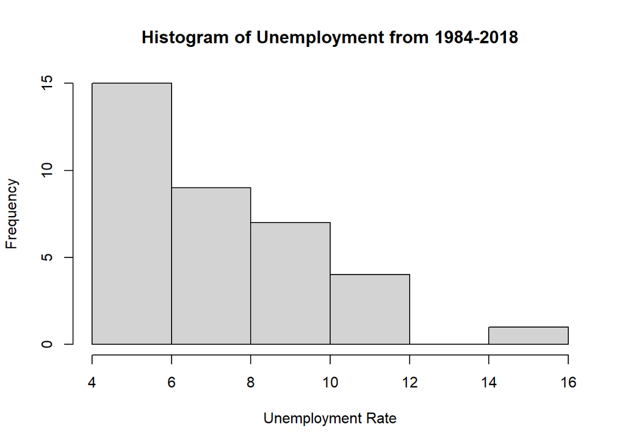

```r
hist(WV_data$value,
     main="Histogram of Unemployment from 1984-2018",
     xlab="Unemployment Rate",
     breaks = 5)
```

In West Virginia,from 1984 to 2018, the unemployment rates ranged from 4.0-15.9%. The histogram displays a positively skewed distribution. 15 of the 36 years were characterized by unemployment rates ranging in lowest interval, 4.0-5.9%.

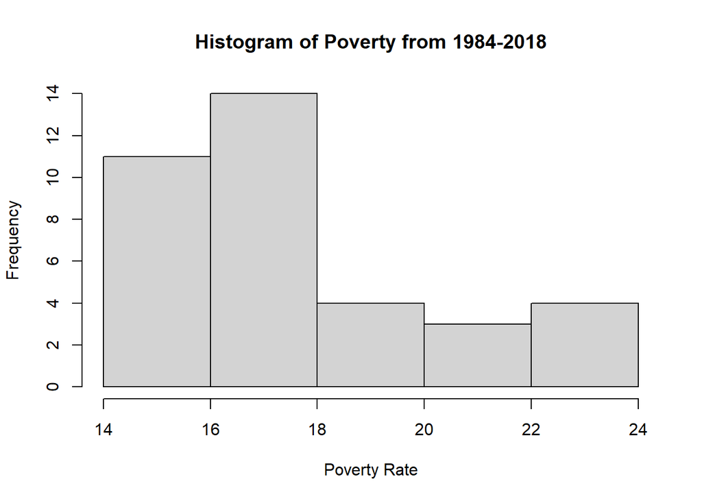

```r
hist(WV_data$poverty,
     main="Histogram of Poverty from 1984-2018",
     xlab="Poverty Rate",
     breaks = 5)
```

In West Virginia, from 1984 to 2018, the annual poverty rates ranged from 14.0% to 23.9%. This is the highest range out of all 8 states examined. Although this range has larger values comparatively, the histogram displays a positively skewed distribution. 25 out of the 36 years were characterized by unemployment rates that fell into the first two intervals, 14.0-15.9% & 16-17.9%.

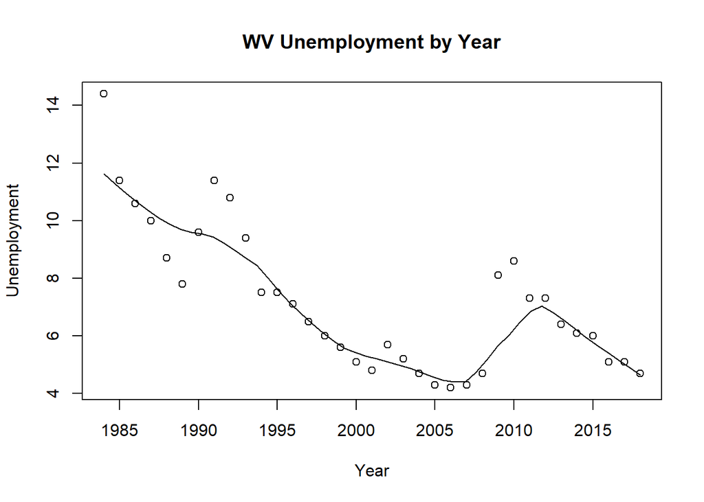

```r
scatter.smooth(WV_data$year, WV_data$value, main="WV Unemployment by Year", xlab = "Year", ylab = "Unemployment", span = 2/8)
```

Unemployment in the state of West Virginia from 1984-2007 was at a declining pace, which shows that the job market is saturated and the state is in good standing. But, prior to the stock market crash of 2008-2009, we can notice that the unemployment rate began to start creeping up and shot up drastically when the stock market crash occurred. Since, then we have seen a steady decline to the rates that were prior to that of the stock market crash.

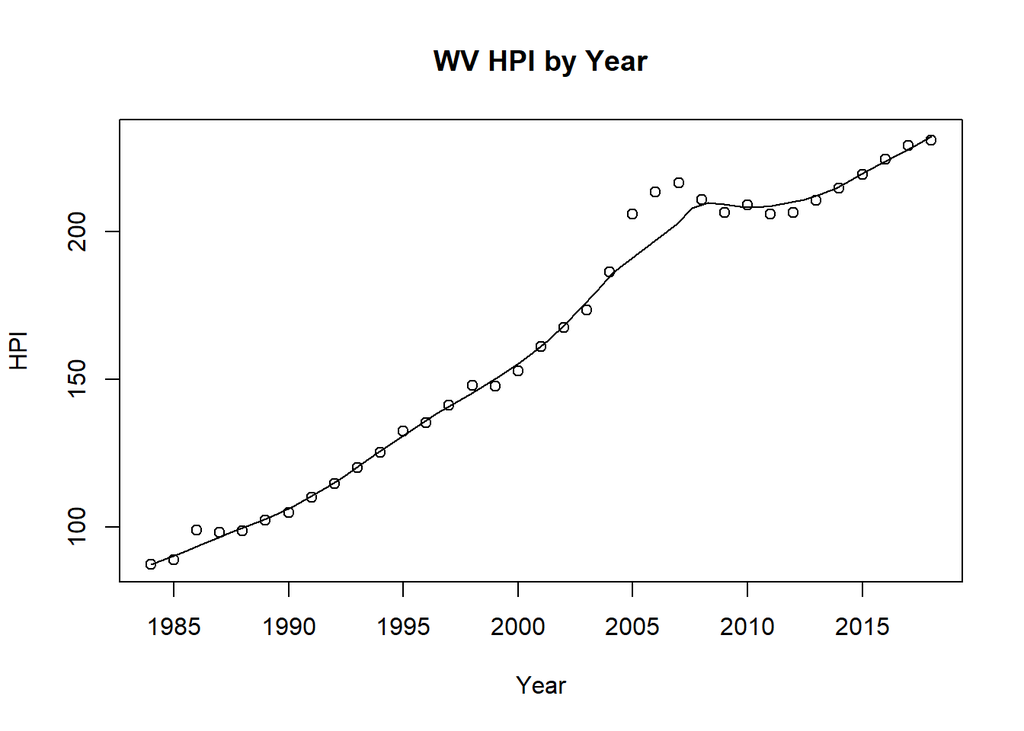

```r
scatter.smooth(WV_data$year, WV_data$HPI, main="WV HPI by Year", xlab = "Year", ylab = "HPI", span = 2/8)
```

The housing price index in the state of West Virginia is much different than that of the poverty level and household income. THe housing price index has been steadily increasing within the state since 1984. THe one dip in the housing price index was the stock market crash of 2008-2009. As the scatter plot shows the housing price index dropped down for about two years and since then has continued to increase at a steady pace.

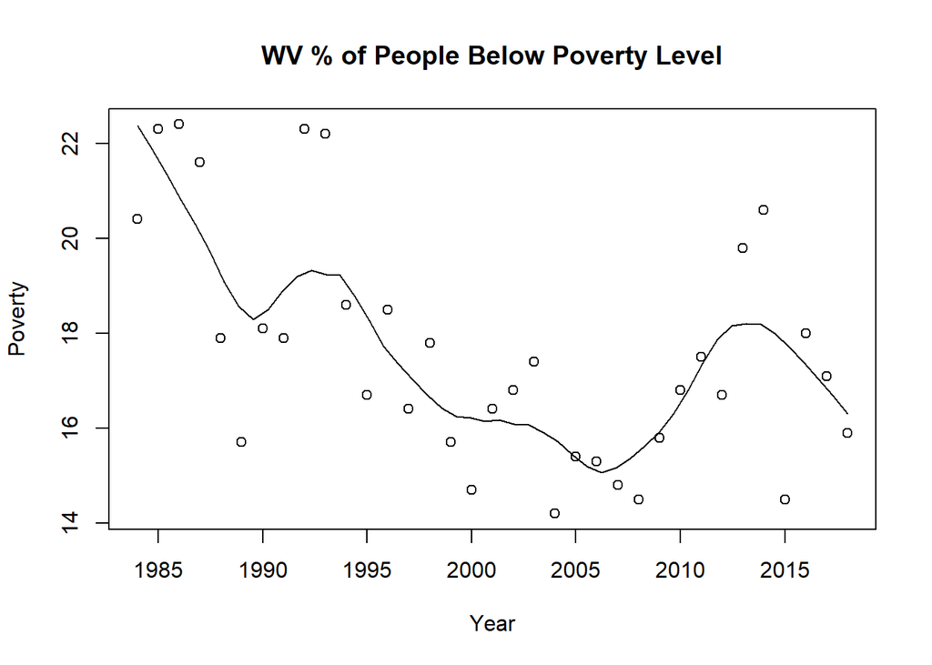

```r
scatter.smooth(x=WV_data$year, y=WV_data$poverty, main="WV % of People Below Poverty Level", xlab = "Year", ylab = "Poverty",  span = 2/8)
```

The poverty, proportion of the population below the poverty line, in West Virginia is pretty consistent with the other scatter plots related to the other variables. As we can in the scatter plot the recession of the 1990s caused the unemployment to shoot up as did the stock market crash in 2008-2009. The stock market crash affected the poverty level negatively for the next few years until the stock market was able to rebound and that is when the proportion of the population below the poverty line began to dwindle.

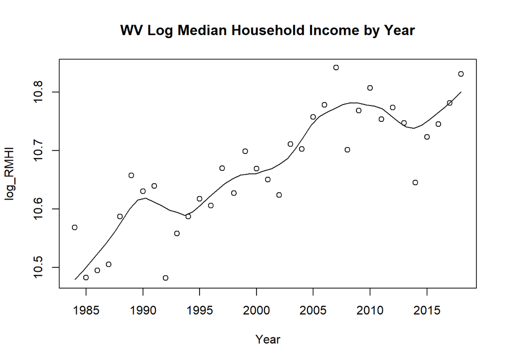

```r
#WV_data$log_RMHI <- as.integer(WV_data$log_RMHI)
scatter.smooth(x=WV_data$year, y=WV_data$log_RMHI, main="WV Log Median Household Income by Year", xlab = "Year", ylab = "log_RMHI", span = 2/8 )
```

As the scatter plot suggests for the state of West Virginia, the median household income does fluctuate from year to year, but also shows a consistent increasing trend throughout the years. The dips on the median household income seem to come at time of economic recessions. In the 1990s, the recession caused a drop in the median household income. Additionally, the stock market crash that occurred in 2008-2009 caused a drop in the median household income. Other than those two instances the median household income within the state has increased steadily.

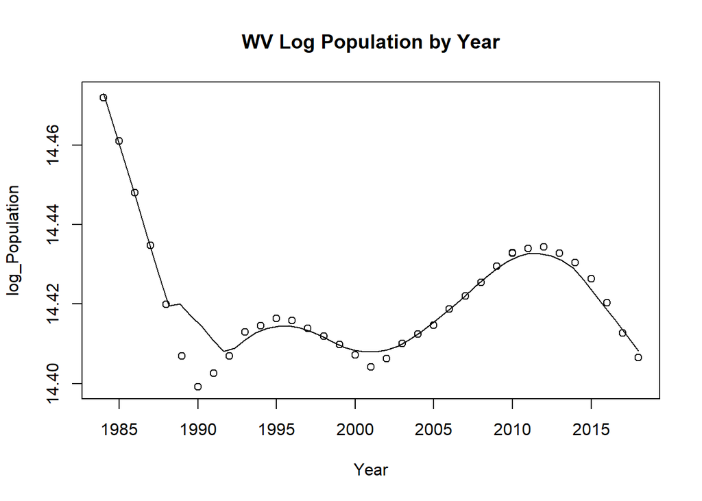

```r
#WV_data$log_pop <- as.integer(WV_data$log_pop)
scatter.smooth(x=WV_data$year, y=WV_data$log_pop, main="WV Log Population by Year", xlab = "Year", ylab = "log_Population", span = 2/8)
```

The log of the population scatter plot for the state of West Virginia shows a steady decrease from 1984-1992. There started to be a slight increase in the population until about 1995 where it began to dwindle down again until 2001. From 2001, the population continued to increase steadily until 2012 and has been declining slightly ever since then.

```r
cor(WV_data$RMHI, WV_data$value)
```

```
## [1] -0.6170457
```

```r
cor(WV_data$HPI, WV_data$value)
```

```
## [1] -0.7138695
```

```r
cor(WV_data$poverty, WV_data$value)
```

```
## [1] 0.6996082
```

```r
cor(WV_data$population, WV_data$value)
```

```
## [1] 0.5144306
```

```r
cor(WV_data$sp500, WV_data$value)
```

```
## [1] 0.1979507
```

```r
cor(WV_data$log_pop, WV_data$value)
```

```
## [1] 0.509377
```

```r
cor(WV_data$log_RMHI, WV_data$value)
```

```
## [1] -0.6322822
```

```r
#run base correlations between categories and dependent variable
```

The correlation between the median household income and unemployment in West Virginia is -0.6170457. The correlation between the median household income and unemployment is that of a large negative correlation. A large negative correlation suggests that in most cases the variables tend to move in inverse directions.

The correlation between the housing price index and unemployment in West Virginia is -0.7138695. The correlation between the housing price index and unemployment is that of a large negative correlation. Just like with the median household income, the housing price index suggests an inverse relationship between unemployment.

The correlation between poverty, the proportion of the population below the poverty line, and unemployment in West Virginia is 0.6996082. The correlation between poverty and unemployment is that of a large positive correlation. A large positive correlation suggests that the two variables tend to move in the same direction unlike the median household income and the housing price index.

The correlation between the population and unemployment is 0.5144306. The correlation between the population and unemployment is that of a large positive correlation. Just like with poverty, the correlation suggests that the two variables tend to move in the same direction of one another.

The correlation between the S&P 500 and unemployment in West Virginia is 0.1979507. The correlation between the S&P 500 and unemployment is a small positive correlation. The correlation shows that there is a small positive relationship between the two variables signifying that the two variables tend to move in the same direction.

The correlation between the log of the population and unemployment in West Virginia is 0.509377. The correlation between the log of the population and unemployment is that of a large positive Correlation. The positive correlation suggests that the two variables mimic one another.

The correlation between the log of the median household income and unemployment in West Virginia is -0.6322822. THe correlation between the log of the median household income and unemployment is a large negative correlation. The large negative correlation suggests that as the log of the median household income increases, the unemployment tends to decrease.

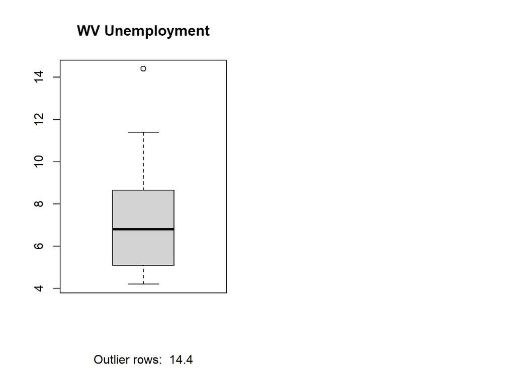

```r
par(mfrow=c(1, 2))  # divide graph area in 2 columns
boxplot(WV_data$value, main="WV Unemployment", sub=paste("Outlier rows: ", boxplot.stats(WV_data$value)$out))  # box plot for 'Unemployment'
```

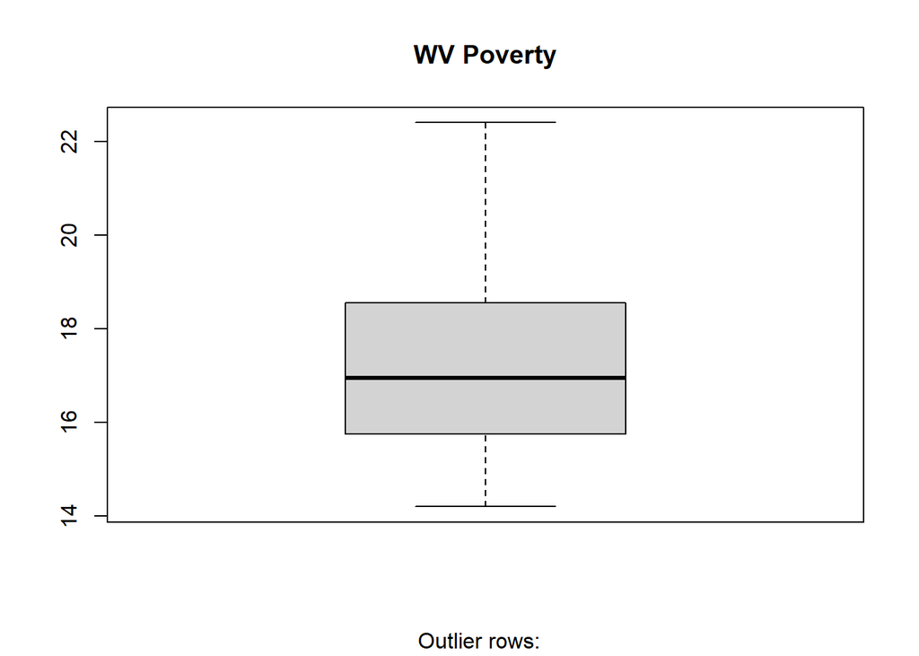

```r
boxplot(WV_data$poverty, main="WV Poverty", sub=paste("Outlier rows: ", boxplot.stats(WV_data$poverty)$out))  # box plot for 'Poverty'
```

```r
#create box plot for poverty level and unemployment level
```

```r
#run multiple linear model for data
WV_reg1 <- lm(value ~ poverty + RMHI + HPI + population + sp500, data = WV_data)
summary(WV_reg1)
```

```
##
## Call:
## lm(formula = value ~ poverty + RMHI + HPI + population + sp500,
##     data = WV_data)
##
## Residuals:
##     Min      1Q  Median      3Q     Max
## -1.8385 -0.7966 -0.3535  0.4722  3.0570
##
## Coefficients:
##               Estimate Std. Error t value Pr(>|t|)
## (Intercept) -5.897e+01  1.377e+01  -4.281 0.000176 ***
## poverty      4.883e-01  1.418e-01   3.443 0.001719 **
## RMHI         3.567e-04  1.278e-04   2.792 0.009038 **
## HPI         -4.956e-02  9.317e-03  -5.320 9.45e-06 ***
## population   2.750e-05  7.756e-06   3.545 0.001310 **
## sp500       -1.221e-02  1.416e-02  -0.862 0.395348
## ---
## Signif. codes:  0 '***' 0.001 '**' 0.01 '*' 0.05 '.' 0.1 ' ' 1
##
## Residual standard error: 1.195 on 30 degrees of freedom
## Multiple R-squared:  0.8009, Adjusted R-squared:  0.7677
## F-statistic: 24.14 on 5 and 30 DF,  p-value: 1.105e-09
```

```r
anova(WV_reg1)
```

```
## Analysis of Variance Table
##
## Response: value
##            Df  Sum Sq Mean Sq F value    Pr(>F)
## poverty     1 105.313 105.313 73.7581 1.396e-09 ***
## RMHI        1   6.319   6.319  4.4257  0.043891 *
## HPI         1  41.472  41.472 29.0460 7.757e-06 ***
## population  1  18.165  18.165 12.7220  0.001236 **
## sp500       1   1.062   1.062  0.7436  0.395348
## Residuals  30  42.835   1.428
## ---
## Signif. codes:  0 '***' 0.001 '**' 0.01 '*' 0.05 '.' 0.1 ' ' 1
```

```r
WV_reg2 <- lm(value ~ poverty + log_RMHI + HPI + log_pop + sp500, data = WV_data)
summary(WV_reg2)
```

```
##
## Call:
## lm(formula = value ~ poverty + log_RMHI + HPI + log_pop + sp500,
##     data = WV_data)
##
## Residuals:
##     Min      1Q  Median      3Q     Max
## -1.6926 -0.7540 -0.3264  0.4607  3.0139
##
## Coefficients:
##               Estimate Std. Error t value Pr(>|t|)
## (Intercept) -9.132e+02  2.079e+02  -4.393 0.000129 ***
## poverty      5.165e-01  1.477e-01   3.496 0.001492 **
## log_RMHI     1.609e+01  5.719e+00   2.814 0.008561 **
## HPI         -5.035e-02  9.467e-03  -5.319 9.47e-06 ***
## log_pop      5.187e+01  1.431e+01   3.624 0.001061 **
## sp500       -1.345e-02  1.431e-02  -0.940 0.354765
## ---
## Signif. codes:  0 '***' 0.001 '**' 0.01 '*' 0.05 '.' 0.1 ' ' 1
##
## Residual standard error: 1.195 on 30 degrees of freedom
## Multiple R-squared:  0.801,  Adjusted R-squared:  0.7678
## F-statistic: 24.15 on 5 and 30 DF,  p-value: 1.1e-09
```

```r
anova(WV_reg2)
```

```
## Analysis of Variance Table
##
## Response: value
##           Df  Sum Sq Mean Sq F value    Pr(>F)
## poverty    1 105.313 105.313 73.7787 1.392e-09 ***
## log_RMHI   1   6.839   6.839  4.7912  0.036524 *
## HPI        1  40.058  40.058 28.0632 1.006e-05 ***
## log_pop    1  18.872  18.872 13.2208  0.001027 **
## sp500      1   1.261   1.261  0.8835  0.354765
## Residuals 30  42.823   1.427
## ---
## Signif. codes:  0 '***' 0.001 '**' 0.01 '*' 0.05 '.' 0.1 ' ' 1
```

```r
WV_linearModelSignificant <- lm(value ~ poverty + log_pop, data = WV_data)
summary(WV_linearModelSignificant)
```

```
##
## Call:
## lm(formula = value ~ poverty + log_pop, data = WV_data)
##
## Residuals:
##     Min      1Q  Median      3Q     Max
## -3.3284 -0.9962 -0.2468  1.0728  4.7333
##
## Coefficients:
##              Estimate Std. Error t value Pr(>|t|)
## (Intercept) -590.9981   288.4061  -2.049   0.0485 *
## poverty        0.6031     0.1321   4.566 6.59e-05 ***
## log_pop       40.7475    20.0659   2.031   0.0504 .
## ---
## Signif. codes:  0 '***' 0.001 '**' 0.01 '*' 0.05 '.' 0.1 ' ' 1
##
## Residual standard error: 1.72 on 33 degrees of freedom
## Multiple R-squared:  0.5462, Adjusted R-squared:  0.5187
## F-statistic: 19.86 on 2 and 33 DF,  p-value: 2.182e-06
```

Next, the data we collected is considered a time series as it was measured on an annual basis. We used the unemployment data that was collected for each state and implemented a time series forecast using the Holt Method.

Time series data typically contains four components: trend, seasonal, cyclical, and random components. Trend is represented by the long-term movements in a data series, whether that be upward or downward. Seasonality is normally represented by repetitions that occur within a single year time period, whereas the cyclical component represents long-term trends that are usually a factor the economy. Typically, seasonal trends are easier to identify than cyclical trends because the time period of a seasonal trend is often known ahead of time. Random components represent the random and unexplained movements within the time series data.

As the unemployment data we collected is shown on an annual basis, we will be focusing on the trend, cyclical, random components in our analysis. The type of analysis we have chosen to focus on is called Holt Exponential Smoothing Method. This method is characterized by incorporating large upward and downward fluctuations in data series. This method is especially relevant because the dataset lacks seasonal variation.

```r
IL_TS <- ts(IL_data$value, start = c(1984), end = c(2018), frequency = 1)
#Stores start, end, and frequency of timeseries data

IL_TData <- window(IL_TS, end = c(2004))
IL_VData <- window(IL_TS, start = c(2005))
#Partitions the training and validation sets
```

In the above section of code, we begin our Holt analysis of IL by creating the time series with the TS function. We set the start and end values of our times series data equal to the time span our data stretches and set the frequency equal to one.

Using the window function we partition our dataset into a training set, IL_TData, and a validation set, IL_VData.

```r
IL_HUser <- ets(IL_TData, model = "AAN", alpha = 0.2, beta = 0.15)
summary(IL_HUser)
```

```
## ETS(A,Ad,N)
##
## Call:
##  ets(y = IL_TData, model = "AAN", alpha = 0.2, beta = 0.15)
##
##   Smoothing parameters:
##     alpha = 0.2
##     beta  = 0.15
##     phi   = 0.8
##
##   Initial states:
##     l = 9.1038
##     b = -0.492
##
##   sigma:  1.3058
##
##      AIC     AICc      BIC
## 77.43215 79.93215 81.61024
##
## Training set error measures:
##                      ME     RMSE       MAE       MPE     MAPE    MASE      ACF1
## Training set 0.01280128 1.139837 0.8591663 -1.525969 14.65093 1.26348 0.5841472
```

```r
#Training data set using user based parameters for alpha and beta for smoothing.
```

It is common for practitioners to provide user supplied values for alpha and beta (smoothing parameters) due to the fact that the computer generated values are known to over-fit models where the data performed well in the sample period, but does not exhibit the same performance in the future. In our data, we compare both user supplied and computer generated smoothing parameters. We then compare the error measures to determine which model is a better fit to our data. We used an alpha = 0.2 and beta = 0.15 when creating the user supplier parameters model.

The ets function above denotes the error, trend, and seasonality of the training set. The first letter in the model string represents that we want the error to be additive, the second letter represents that fact that we expect the trend type to be additive, and the third letter, “N”, represents the fact that we do not intend on incorporating seasonality into our model.

```r
IL_HCmp <- ets(IL_TData, model = "AAN")
summary(IL_HCmp)
```

```
## ETS(A,A,N)
##
## Call:
##  ets(y = IL_TData, model = "AAN")
##
##   Smoothing parameters:
##     alpha = 0.9999
##     beta  = 1e-04
##
##   Initial states:
##     l = 8.3553
##     b = -0.2338
##
##   sigma:  0.9784
##
##      AIC     AICc      BIC
## 68.58121 72.58121 73.80382
##
## Training set error measures:
##                     ME      RMSE       MAE      MPE     MAPE      MASE
## Training set 0.1120952 0.8803193 0.6387882 1.287488 10.53478 0.9393944
##                   ACF1
## Training set 0.0652965
```

```r
#Training data set using computer based parameters for alpha and beta for smoothing.
```

We replicated the ets function using the computer generated smoothing parameters and obtained the output above. By comparing the root mean squared error(RMSE) and the mean absolute percentage error(MAPE) we can assess the fitness of the user supplier and computer generate models. The user supplied model has a higher RMSE and MAPE indicating that the computer generated model provides a better overall fit for making a forecast.

```r
IL_nV <- length(IL_VData)
IL_fUser <- forecast(IL_HUser, h = IL_nV)
IL_fCmp <- forecast(IL_HCmp, h = IL_nV)
```

The length function is used to set the number of observations equal to the length of the validation set. Then the forecast function is utilized to make a forecast based on the observations in our training set.

```r
accuracy(IL_fUser,IL_VData)
```

```
##                      ME     RMSE       MAE       MPE     MAPE     MASE
## Training set 0.01280128 1.139837 0.8591663 -1.525969 14.65093 1.263480
## Test set     0.22556242 2.075490 1.8905876 -5.598974 27.98416 2.780276
##                   ACF1 Theil's U
## Training set 0.5841472        NA
## Test set     0.6727078  1.402801
```

```r
accuracy(IL_fCmp,IL_VData)
```

```
##                     ME      RMSE       MAE       MPE     MAPE      MASE
## Training set 0.1120952 0.8803193 0.6387882  1.287488 10.53478 0.9393944
## Test set     3.0944149 3.8292855 3.3229011 37.967956 43.12811 4.8866193
##                   ACF1 Theil's U
## Training set 0.0652965        NA
## Test set     0.6934401  2.220317
```

The accuracy function is used to test the error term outputs that were created using the training set. When comparing the accuracy function results we see conflicting results in our validation set. The test set shows that the RMSE and MAPE of the user generated model provides a better fit for the performance of our data. Ultimately, we decided to continue the process using the computer generated model, but the user supplied model would work just as well.

```r
IL_HFinal <- ets(IL_TS, model = "AAN")
forecast(IL_HFinal, h=1)
```

```
##      Point Forecast    Lo 80    Hi 80    Lo 95    Hi 95
## 2019        4.41789 2.851058 5.984722 2.021628 6.814152
```

Finally, everything is brought together with the ets and forecast functions to forecast the unemployment level for the next period, 2019. The forecast generated shows that the expected value of the Illinois unemployment level in December 2019 is equal to 4.42% based on the trends that is observed in our model. Based on the forecast we expect that the unemployment will range from 2.85% to 5.98% at a 80% confidence interval. Additionally, we can be 95% confident that the unemployment value will fall between 2.02% and 6.81%. Based on the actual unemployment rate in IL for December 2019 of 3.5% our model was accurate at predicting the unemployment value at both the 95% and 80% confidence intervals.

```r
WV_TS <- ts(WV_data$value, start = c(1984), end = c(2018), frequency = 1)
#Stores start, end, and frequency of timeseries data

WV_TData <- window(WV_TS, end = c(2004))
WV_VData <- window(WV_TS, start = c(2005))
#Partitions the training and validation sets
```

```r
WV_HUser <- ets(WV_TData, model = "AAN", alpha = 0.2, beta = 0.15)
summary(WV_HUser)
```

```
## ETS(A,Ad,N)
##
## Call:
##  ets(y = WV_TData, model = "AAN", alpha = 0.2, beta = 0.15)
##
##   Smoothing parameters:
##     alpha = 0.2
##     beta  = 0.15
##     phi   = 0.8
##
##   Initial states:
##     l = 12.7771
##     b = -1.5609
##
##   sigma:  1.6369
##
##      AIC     AICc      BIC
## 86.92211 89.42211 91.10020
##
## Training set error measures:
##                      ME     RMSE      MAE       MPE     MAPE     MASE     ACF1
## Training set -0.1320942 1.428802 1.148726 -3.883647 14.15979 1.228584 0.504785
```

```r
#Training data set using user based parameters for alpha and beta for smoothing.
```

```r
WV_HCmp <- ets(WV_TData, model = "AAN")
summary(WV_HCmp)
```

```
## ETS(A,Ad,N)
##
## Call:
##  ets(y = WV_TData, model = "AAN")
##
##   Smoothing parameters:
##     alpha = 0.9999
##     beta  = 2e-04
##     phi   = 0.8417
##
##   Initial states:
##     l = 15.9638
##     b = -1.8651
##
##   sigma:  1.1154
##
##      AIC     AICc      BIC
## 74.81012 80.81012 81.07726
##
## Training set error measures:
##                       ME      RMSE       MAE       MPE     MAPE      MASE
## Training set -0.07675973 0.9735733 0.6947987 -1.828428 8.590638 0.7431002
##                  ACF1
## Training set 0.271826
```

```r
#Training data set using computer based parameters for alpha and beta for smoothing.
```

With West Virginia, we setup the datasets and partitioned them into training and validation sets following similar steps to Illinois.

The user supplied model for the state of West Virginia has a higher RMSE and MAPE at 1.4288 and 14.1598, respectively. The computer generated model has a RMSE of 0.9736 and a MAPE of 8.5906 indicating that the computer generated model provides a better overall fit to our forecast.

```r
WV_nV <- length(WV_VData)
WV_fUser <- forecast(WV_HUser, h = WV_nV)
WV_fCmp <- forecast(WV_HCmp, h = WV_nV)
```

```r
accuracy(WV_fUser,WV_VData)
```

```
##                      ME     RMSE      MAE       MPE     MAPE     MASE      ACF1
## Training set -0.1320942 1.428802 1.148726 -3.883647 14.15979 1.228584 0.5047850
## Test set      1.7441115 2.355068 1.857933 23.491691 26.16469 1.987094 0.7058261
##              Theil's U
## Training set        NA
## Test set      1.672258
```

```r
accuracy(WV_fCmp,WV_VData)
```

```
##                       ME      RMSE       MAE       MPE      MAPE      MASE
## Training set -0.07675973 0.9735733 0.6947987 -1.828428  8.590638 0.7431002
## Test set      1.62448769 2.2608082 1.7776928 21.469084 25.065397 1.9012758
##                   ACF1 Theil's U
## Training set 0.2718260        NA
## Test set     0.7051023  1.604304
```

The accuracy function confirms that the computer generated model is a better overall fit to the data we are using to create the model. This is due to the fact that once again the validation set exhibits a lower RMSE and MAPE under the computer generated model.

```r
WV_HFinal <- ets(WV_TS, model = "AAN")
forecast(WV_HFinal, h=1)
```

```
##      Point Forecast    Lo 80    Hi 80    Lo 95   Hi 95
## 2019       4.699914 3.200919 6.198909 2.407398 6.99243
```

The forecast for West Virginia shows us that the expected value of the unemployment level in December 2019 is equal to 4.70% based on the trends that were observed in the computer generated model. At an 80% confidence interval we expect West Virginia’s unemployment level to range from 3.20% to 6.20%. Additionally, we can be 95% confident that the unemployment rate will be in the 2.41% to 6.99% level. The actual unemployment rate for the State of West Virginia in December 2019 is 5%. Our model is accurate at both the 95% and 80% confidence intervals. 5% is also fairly close to the point estimate at 4.7% further signifying that our model produces accurate results.